# Breast Cancer Prediction Project

### Principal Component Analysis

In data sets with many predictors visualizing relationships is difficult and fitting models to all predictors leads to over-training. For high-dimensional data using a smaller set of the most predictive features produces better models. The prcomp function performs principle components analysis which orders them by highest to lowest variance.

Perform a principal component analysis of the scaled matrix.

```r
pca <- prcomp(x_scaled)
summary(pca)
```

```
## Importance of components:
##                          PC1   PC2    PC3   PC4   PC5    PC6    PC7    PC8
## Standard deviation     3.644 2.386 1.6787 1.407 1.284 1.0988 0.8217 0.6904
## Proportion of Variance 0.443 0.190 0.0939 0.066 0.055 0.0403 0.0225 0.0159
## Cumulative Proportion  0.443 0.632 0.7264 0.792 0.847 0.8876 0.9101 0.9260
##                           PC9   PC10   PC11    PC12    PC13    PC14    PC15
## Standard deviation     0.6457 0.5922 0.5421 0.51104 0.49128 0.39624 0.30681
## Proportion of Variance 0.0139 0.0117 0.0098 0.00871 0.00805 0.00523 0.00314
## Cumulative Proportion  0.9399 0.9516 0.9614 0.97007 0.97812 0.98335 0.98649
##                           PC16    PC17    PC18    PC19    PC20  PC21    PC22
## Standard deviation     0.28260 0.24372 0.22939 0.22244 0.17652 0.173 0.16565
## Proportion of Variance 0.00266 0.00198 0.00175 0.00165 0.00104 0.001 0.00091
## Cumulative Proportion  0.98915 0.99113 0.99288 0.99453 0.99557 0.997 0.99749
##                           PC23   PC24    PC25    PC26    PC27    PC28    PC29
## Standard deviation     0.15602 0.1344 0.12442 0.09043 0.08307 0.03987 0.02736
## Proportion of Variance 0.00081 0.0006 0.00052 0.00027 0.00023 0.00005 0.00002
## Cumulative Proportion  0.99830 0.9989 0.99942 0.99969 0.99992 0.99997 1.00000
##                          PC30
## Standard deviation     0.0115
## Proportion of Variance 0.0000
## Cumulative Proportion  1.0000
```

What proportion of variance is explained by the first principal component? *0.443*

How many principal components are required to explain at least 90% of the variance? *At PC7 cumulative variance is 91%*

Plot the first two principal components with color representing tumor type (benign/malignant).

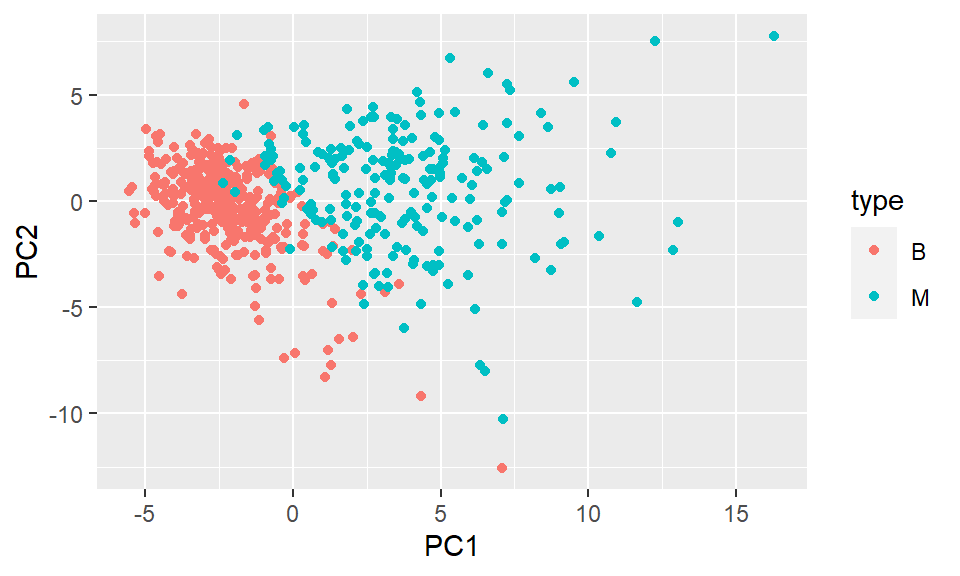

```r
data.frame(pca$x[,1:2], type = brca$y) %>%
  ggplot(aes(PC1, PC2, color = type)) +
  geom_point()
```

Make a boxplot of the first 10 PCs grouped by tumor type.

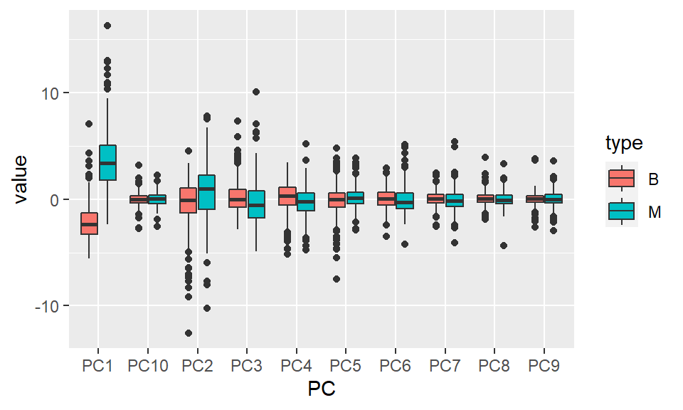

```r
data.frame(type = brca$y, pca$x[,1:10]) %>%
  gather(key = "PC", value = "value", -type) %>%
  ggplot(aes(PC, value, fill = type)) +
  geom_boxplot()
```

Which PCs are significantly different enough by tumor type that there is no overlap in the IQRs for benign and malignant samples? PC1

## Training Models

In order to train a model and test predictions the data must be split into two sets. Set the seed to 1, then create a data partition splitting brca$y and the scaled version of the brca$x matrix into 80/20 train/test set.

```r
set.seed(1, sample.kind = "Rounding")
test_index <- createDataPartition(brca$y, times = 1, p = 0.2, list = FALSE)
test_x <- x_scaled[test_index,]
test_y <- brca$y[test_index]
train_x <- x_scaled[-test_index,]
train_y <- brca$y[-test_index]
```

Check that the training and test sets have similar proportions of benign and malignant tumors.

What proportion of the training set is benign? 0.628 What proportion of the test set is benign? 0.626

### K-Means Clustering

K-means clustering defines $k$ clusters where each observations is assigned to the cluster whose center is the closest distance to the observation.

The predict_kmeans() function defined here takes two arguments: a matrix of observations $x$ and a k-means object $k$ and assigns each row of $x$ to a cluster from $k$. Set the seed to 3. Perform k-means clustering on the training set with 2 centers and assign the output to k.

```r
predict_kmeans <- function(x, k) {
  centers <- k$centers
  distances <- sapply(1:nrow(x), function(i){
    apply(centers, 1, function(y) dist(rbind(x[i,], y)))
  })
  max.col(-t(distances))
}

set.seed(3, sample.kind = "Rounding")
k <- kmeans(train_x, centers = 2)
kmeans_preds <- ifelse(predict_kmeans(test_x, k) == 1, "B", "M")
```

What is the overall accuracy?

```r
mean(kmeans_preds == test_y)
```

```
## [1] 0.922
```

```r
sensitivity(factor(kmeans_preds), test_y, positive = "B")
```

```
## [1] 0.986
```

### Logistic Regression

Logistic regression is regression model for a categorical outcome where outcome has been assigned values of 0 and 1 the regression is performed as if the outcome was continuous. By applying a logistic transformation the prediction to log odds which is constrained between 0 and 1. Logistic regression models are not very flexible

Fit a logistic regression model on the training set with caret::train() using all predictors.

```r
# caret package loaded
train_glm <- train(train_x, train_y, method = "glm")
```

What is the accuracy of the logistic regression model?

```r
glm_preds <- predict(train_glm, test_x)
mean(glm_preds == test_y)
```

```
## [1] 0.957
```

### Linear Discriminant Analysis (LDA) and Quadratic Discriminant Analysis (QDA)

QDA is a version a naive bayes where the distributions of the probability of outcomes (Y=1 and Y=0) are assumed to be multivariate normal. It estimates averages, standard deviations and correlations for each case for both outcomes. It does not work well with mmultiple predictors, and the distributions of outcomes is not always known. LDA, instead, assumes the correlation structure is the same for all classes which simplifies trying to correlate multiple predictors, but reduces the conditional probability of the outcome to a linear boundary which is not flexible.

Train an LDA model and a QDA model on the training set. Make predictions on the test set using each model.

```r
train_lda <- train(train_x, train_y, method = "lda")
train_qda <- train(train_x, train_y, method = "qda")
```

```r
qda_preds <- predict(train_qda, test_x)
mean(qda_preds == test_y)
```

```
## [1] 0.957
```

What is the accuracy of the LDA model?

```r
lda_preds <- predict(train_lda, test_x)
mean(lda_preds == test_y)
```

```
## [1] 0.991
```

### Loess Model

LOESS is a type of local weighted regression (also called smoothing) than looks for trends in noisy data by approximating small “neighborhoods” of data points and defining a best-fit line between points. The end results is a smoothed curve rather than a estimated straight line average. LOESS assigns a reduced weight to data points further from the center of the neighborhood.

Set the seed to 5, then fit a loess model using the caret package. You will need to install the gam package. Use the default tuning grid. This may take several minutes; ignore warnings.

```r
set.seed(5, sample.kind = "Rounding")
train_loess <- train(train_x, train_y, method = "gamLoess")
```

What is the accuracy of the loess model?

```r
loess_preds <- predict(train_loess, test_x)
mean(loess_preds == test_y)
```

```
## [1] 0.983
```

### K-Nearest Neighbors Model

K-Nearest Neighbors is a classification model that assumes similar observations are close to each other when distance is calculated. kNN averages distances and assigns $k$ “neighborhoods” or clusters of similar observations. Different distances calculations can be used such as Euclidean distance.

Set the seed to 7. Train a k-nearest neighbors model using the caret package. Try odd values of $k$ from 3 to 21. Use the final model to generate predictions.

```r
set.seed(7, sample.kind = "Rounding")
tuning <- data.frame(k = seq(3, 21, 2))
train_knn <- train(train_x, train_y,
                   method = "knn",
                   tuneGrid = tuning)
```

What is the final value of k used in the model?

```r
train_knn$bestTune
```

```
##    k
## 8 17
```

What is the accuracy of the kNN model?

```r
knn_preds <- predict(train_knn, test_x)
mean(knn_preds == test_y)
```

```
## [1] 0.957
```

### Random Forest Model

Random Forest is a type of classification and regression tree (CART) algorithm which generates a large number of trees with smaller subsets of predictors then averages the outcomes.

Set the seed to 9. Train a random forest model using the caret package. Test mtry values of c(3, 5, 7, 9). Use the argument importance = TRUE so that feature importance can be extracted.

```r
set.seed(9, sample.kind = "Rounding")
tuning <- data.frame(mtry = c(3, 5, 7, 9))
train_rf <- train(train_x, train_y,
                  method = "rf",
                  tuneGrid = tuning,
                  importance = TRUE)
```

What value of mtry gives the highest accuracy?

```r
train_rf$bestTune
```

```
##   mtry
## 1    3
```

What is the accuracy of the random forest model?

```r
rf_preds <- predict(train_rf, test_x)
mean(rf_preds == test_y)
```

```
## [1] 0.974
```

What is the most important variable?

```r
varImp(train_rf)
```

```
## rf variable importance
##
##   only 20 most important variables shown (out of 30)
##
##                   Importance
## area_worst             100.0
## radius_worst            87.7
## concave_pts_worst       85.7
## perimeter_worst         85.5
## concave_pts_mean        72.1
## area_se                 67.3
## concavity_worst         63.5
## area_mean               61.4
## texture_worst           59.9
## perimeter_mean          55.2
## concavity_mean          55.2
## texture_mean            55.0
## radius_se               49.8
## smoothness_worst        49.1
## radius_mean             49.0
## perimeter_se            45.0
## compactness_worst       39.3
## symmetry_worst          35.3
## smoothness_mean         30.6
## fractal_dim_worst       27.8
```

*area_worst most important variable*

### Creating an Ensemble

Ensembles combine algorithms’ results to achieve better predictions.

Create an ensemble using the predictions from the 7 models created in the previous exercises: k-means, logistic regression, LDA, QDA, loess, k-nearest neighbors, and random forest. Use the ensemble to generate a majority prediction of the tumor type.

```r
ensemble <- cbind(glm = glm_preds=="B", lda = lda_preds=="B", qda = qda_preds=="B", loess = loess_preds=="B",
                  rf = rf_preds=="B", knn = knn_preds=="B", kmeans = kmeans_preds=="B")

ensemble_preds <- ifelse(rowMeans(ensemble) > 0.5, "B", "M")
```

What is the accuracy of the ensemble prediction?

```r
mean(ensemble_preds == test_y)
```

```
## [1] 0.983
```

Make a table of the accuracies of the 7 models and the accuracy of the ensemble model.

```r
models <- c("K Means", "Logistic Regression", "LDA", "QDA", "Loess", "K-Nearest Neighbors", "Random Forest", "Ensemble")
accuracy <- c(mean(kmeans_preds == test_y),
              mean(glm_preds == test_y),
              mean(lda_preds == test_y),
              mean(qda_preds == test_y),
              mean(loess_preds == test_y),
              mean(knn_preds == test_y),
              mean(rf_preds == test_y),
              mean(ensemble_preds == test_y))
data.frame(Model = models, Accuracy = accuracy)
```

```
##                 Model Accuracy
## 1             K Means    0.922
## 2 Logistic Regression    0.957
## 3                 LDA    0.991
## 4                 QDA    0.957
## 5               Loess    0.983
## 6 K-Nearest Neighbors    0.957
## 7       Random Forest    0.974
## 8            Ensemble    0.983
```

Which of these models has the highest accuracy? *LDA*